# 簡單的繪圖

郭耀仁

2017-09-06

## 視覺化的力量

- [Hans Rosling](https://www.youtube.com/watch?v=jbkSRLYSojo)

> He rose to international celebrity status after producing a [Ted Talk](https://www.ted.com/talks/hans_rosling_shows_the_best_stats_you_ve_ever_seen?language=zh-tw) in which he promoted the use of data to explore development issues. [Hans Rosling - Wikipedia](https://en.wikipedia.org/wiki/Hans_Rosling)

## 視覺化的力量（2）

- Less than 5 minutes
- 200 years
- 200+ countries
- 120,000+ observations

## 玩具資料（Toy datasets）

- 在 RStudio 命令列輸入 `data()` 可以看有哪些玩具資料可以直接使用

```r
cars
iris
mtcars

?cars #help(cars)
?iris #help(iris)
?mtcars #help(mtcars)
```

## 觀察玩具資料

- 使用函數觀察玩具資料

```r
head(cars)
tail(cars)
dim(cars)
nrow(cars)
ncol(cars)
summary(cars)
str(cars)
```

## Getting Started

- Generic X-Y plotting
- $y = x^2$
- `xlim` 調整 X 軸上下界
- `ylim` 調整 Y 軸上下界

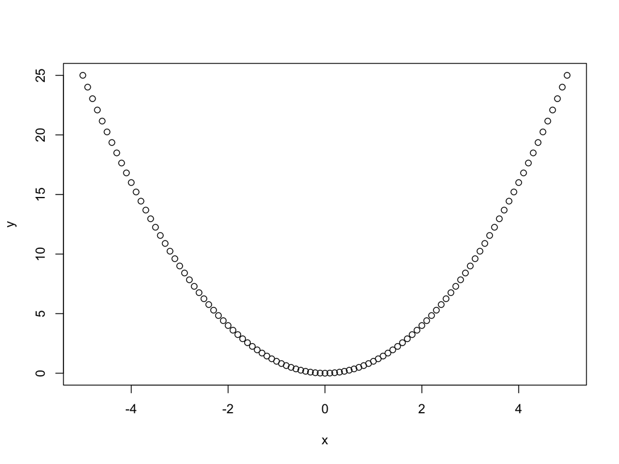

```r
x <- seq(from = -5, to = 5, by = 0.1)
y <- x^2
plot(x, y)
```

## Getting Started(2)

- `xlab` X 軸標籤
- `ylab` Y 軸標籤
- `main` 標題
- `sub` 副標題

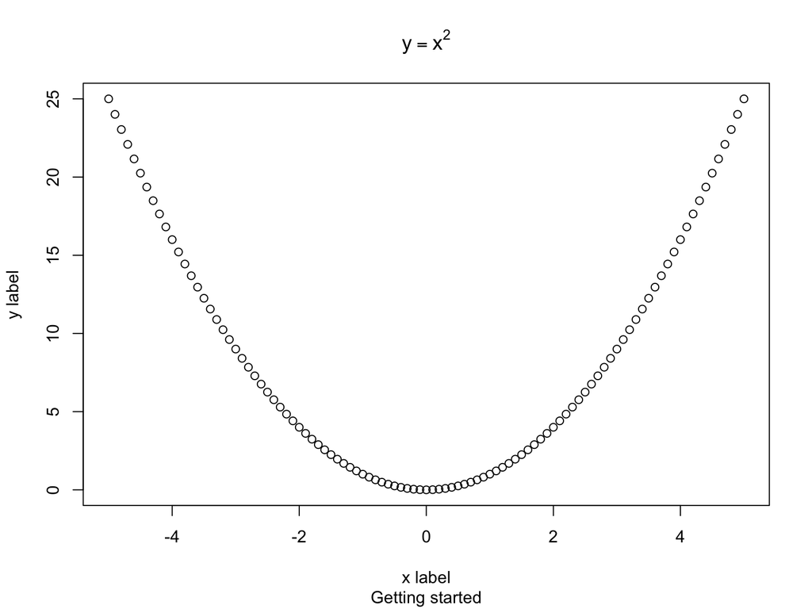

```r
plot(x, y, xlab = "x label", ylab = "y label",
     main = expression(y == x^2), sub = "Getting started")
```

## Getting Started(3)

- `pch` 標記的樣式

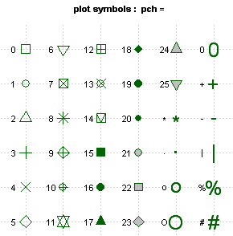

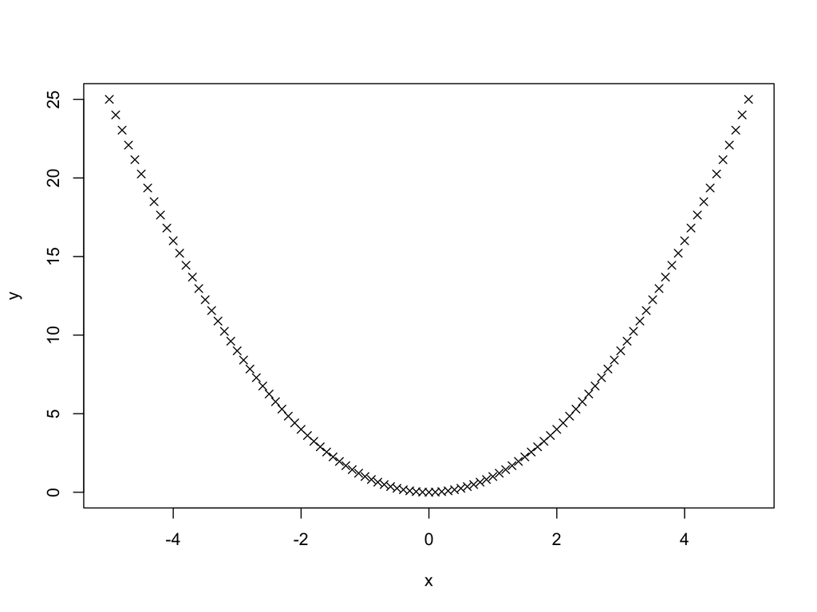

```r
plot(x, y, pch = 4)
```

## Getting Started(4)

- `type = "l"` 描繪線條
- `lty` 線條的樣式
- `lwd` 線條的寬度

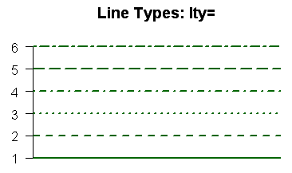

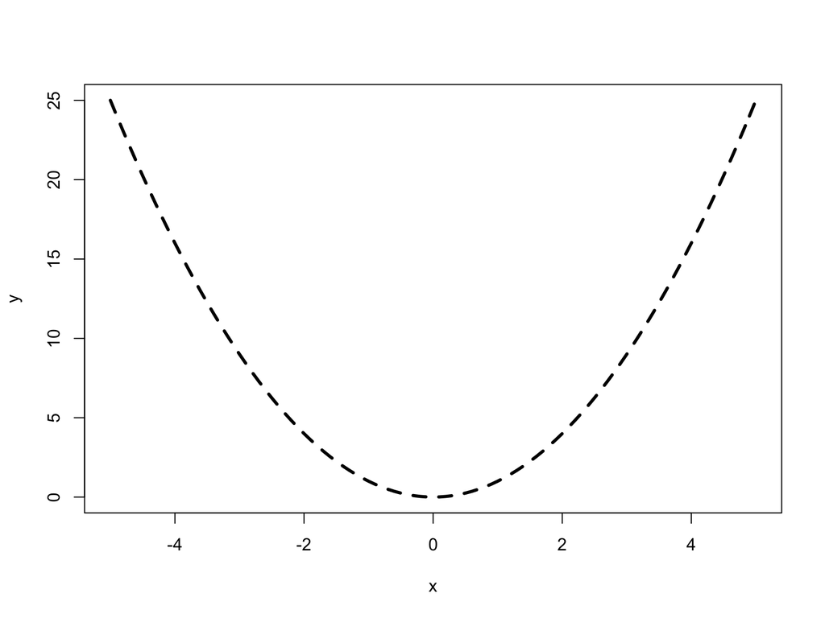

```r
plot(x, y, type = "l", lty = 2, lwd = 3)
```

## Getting Started(5)

- `col` 顏色
  - `col.axis`
  - `col.lab`
  - `col.main`
  - `col.sub`
  - `bg`

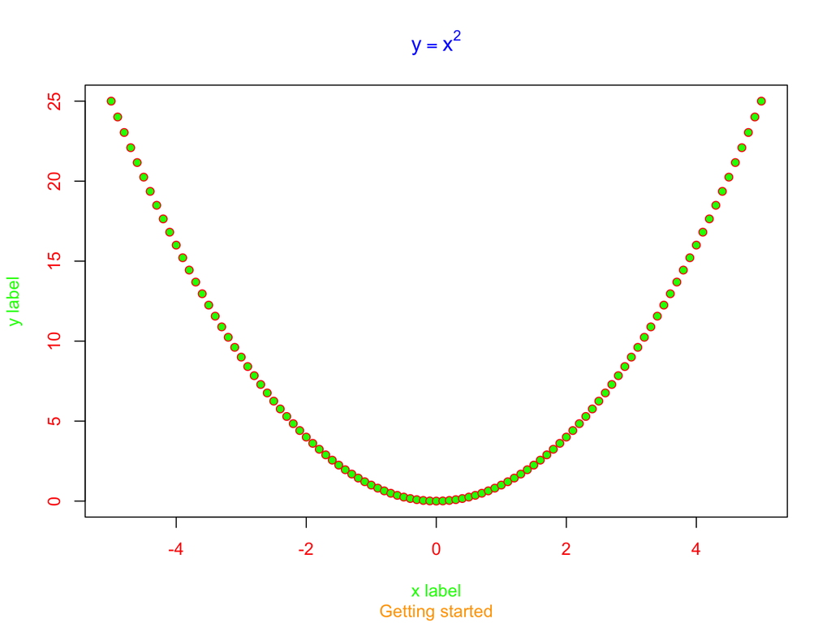

```r
plot(x, y, xlab = "x label", ylab = "y label",
     main = expression(y == x^2), sub = "Getting started",
     col.axis = "red", col.lab = "green", col.main = "blue",
     col.sub = "orange", col = "red", bg = "green", pch = 21)
```

```r
# bg 僅對 pch 21~25 有效
```

## Getting Started(6)

- 重要的 `par()` 參數
  - `las` 軸標籤的方向
  - `mar` 圖的上下左右邊界寬
  - `mfrow` 子圖形的 row 數與 col 數
- 利用 `dev.off()` 恢復預設值

```r
par("las")
par("mar")
par("mfrow")
```

## Getting Started(7)

- `text()` 加入文字

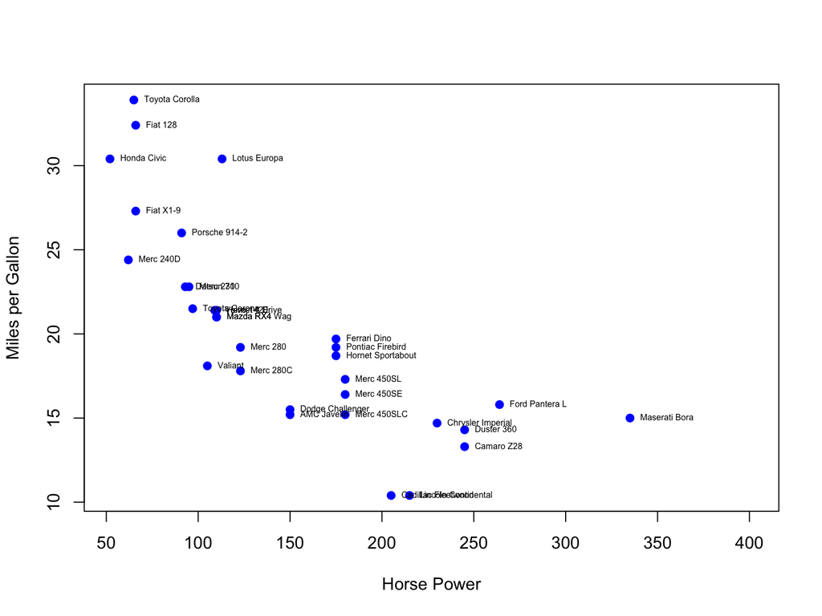

```r
plot(mtcars$hp, mtcars$mpg, xlim = c(min(mtcars$hp), max(mtcars$hp)*1.2), pch = 21, col = "blue", bg = "blue", xlab = "Horse Power", ylab = "Miles per Gallon")
text(mtcars$hp, mtcars$mpg, labels = row.names(mtcars), cex = 0.5, pos = 4)
```

## Getting Started(8)

- `legend()` 加入圖例

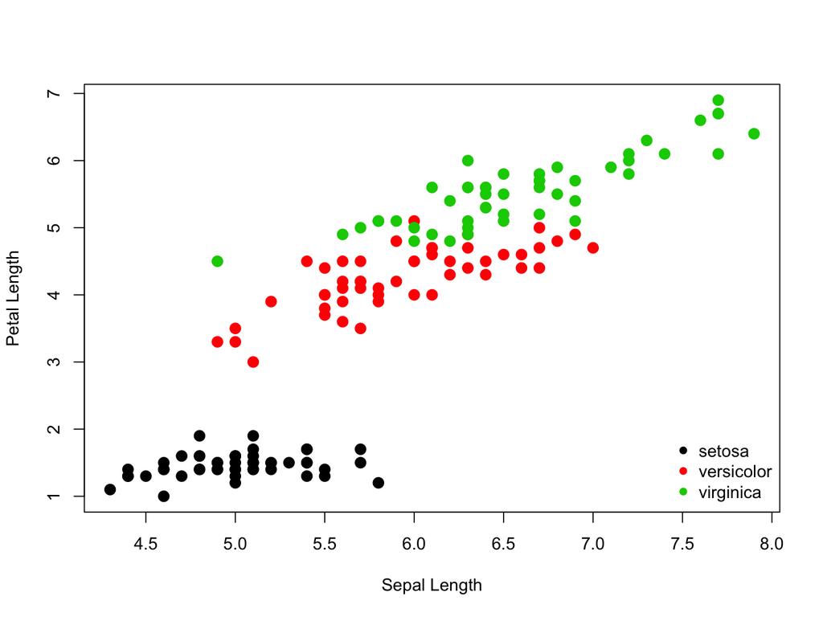

```r
plot(iris$Sepal.Length, iris$Petal.Length, col = iris$Species,
     xlab = "Sepal Length", ylab = "Petal Length", pch = 16, cex = 1.5)
legend("bottomright", col = 1:3, legend = levels(iris$Species), pch = 16, bty = "n")
```

## Getting Started(9)

- 練習

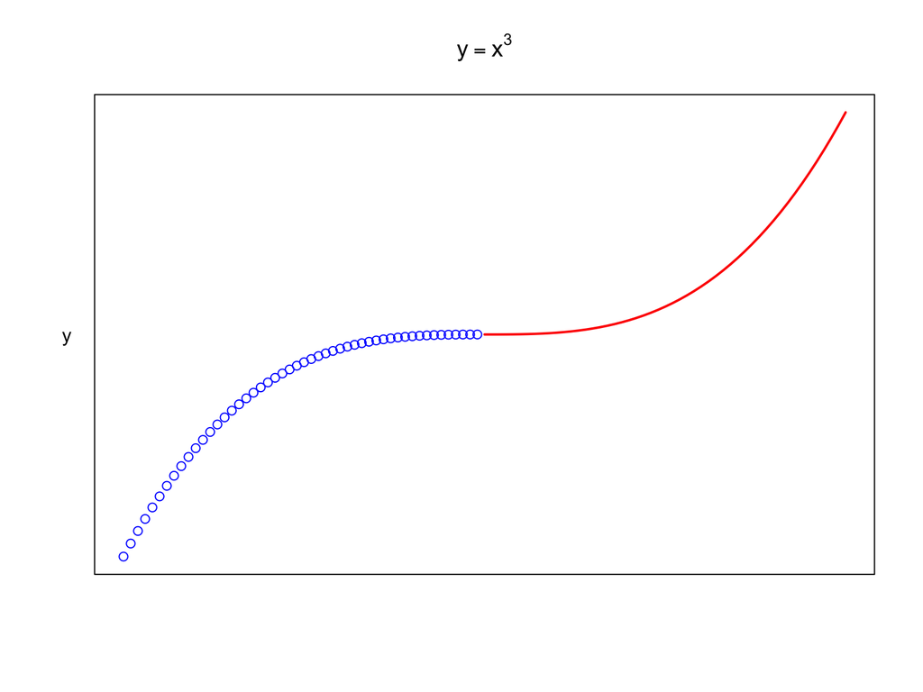

```r
x <- seq(-5, 5, by = 0.1)
y <- x**3
plot(x, y, type = "n", xaxt = "n", yaxt = "n", ylab = "", xlab = "")
title(expression(y == x^3))
mtext("y", side = 2, line = 1, las = 1)
points(x[x < 0], y[y < 0], col = "blue")
lines(x[x >= 0], y[y >= 0], col = "red", lwd = 2)
```

## 散佈圖

- `plot()` 繪製散佈圖

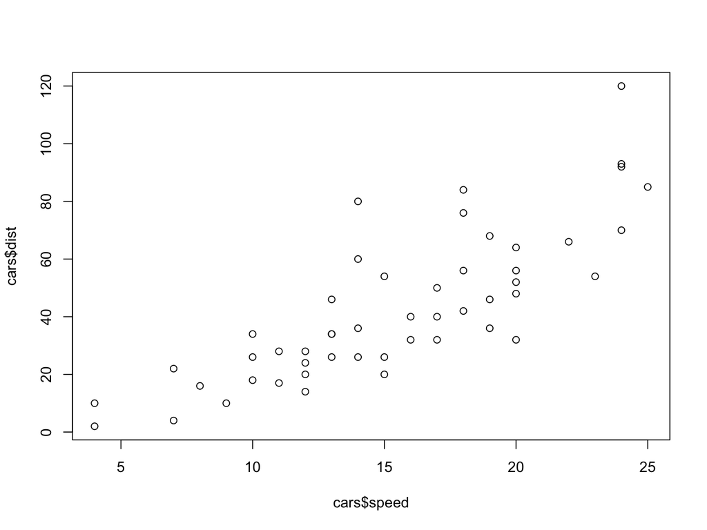

```r
plot(cars$speed, cars$dist)
```

## 散佈圖（2）

- 練習加入標題（`main`）、X 軸標籤（`xlab`）與 Y 軸標籤（`ylab`）

## 散佈圖（3）

- 加入 **fit line**

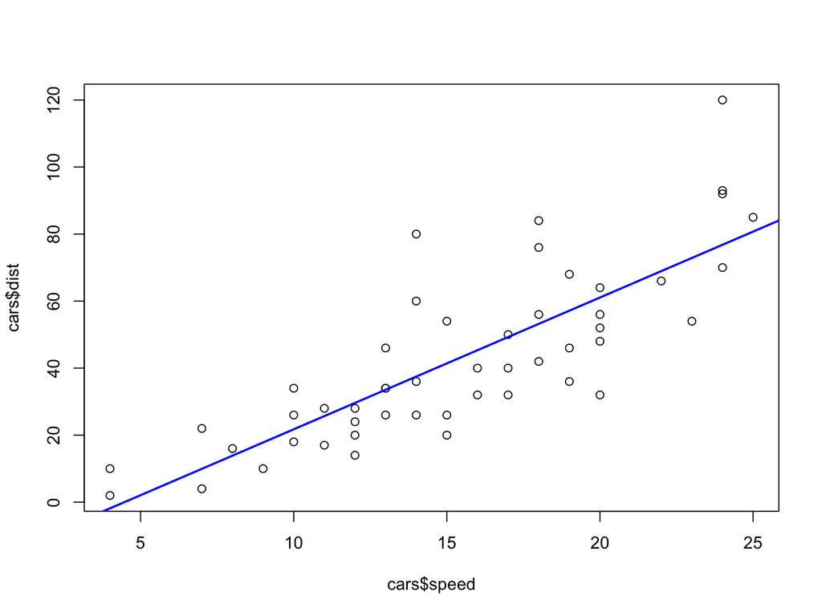

```r
plot(cars$speed, cars$dist)
fitline <- lm(dist ~ speed, data = cars)
abline(fitline, lwd = 2, col = "blue")
```

## 線圖

- `plot(..., type = "l")` 繪製線圖

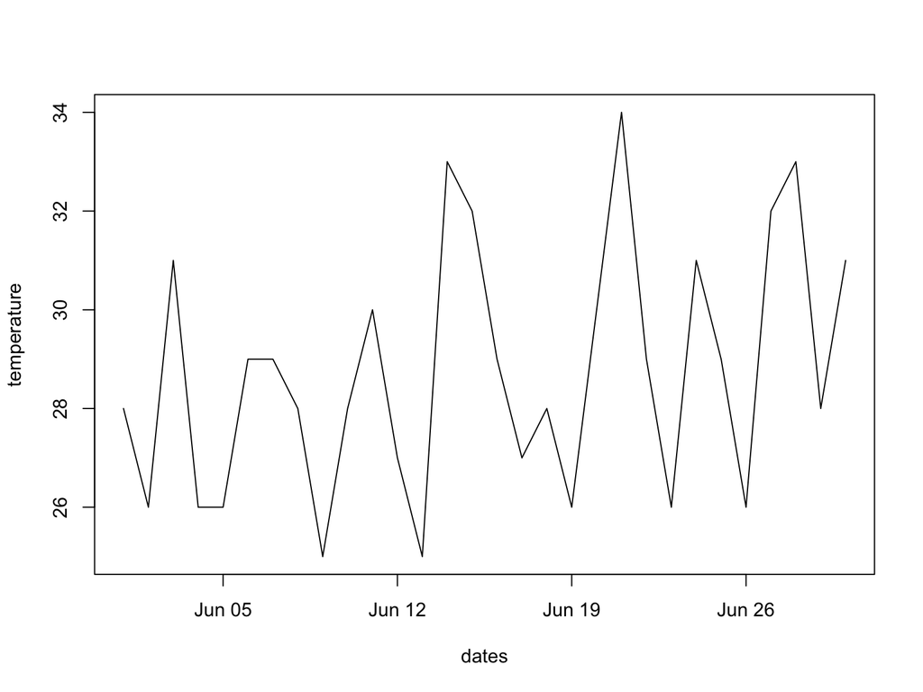

```r
temperature <- round(runif(30) * 10 + 25)
dates <- as.Date("2017-06-01"):as.Date("2017-06-30")
dates <- as.Date(dates, origin = "1970-01-01")
plot(x = dates, y = temperature, type = "l")
```

## 線圖（2）

- 練習調整 `ylim` 參數

## 直方圖

- 繪製標準常態分佈與均勻分布
- `runif()` 函數可以幫你產生 0 到 1之間**均勻分配**的隨機數
- `rnorm()` 函數可以幫你產生**標準常態分配**的隨機數
- 調整 `breaks` 參數

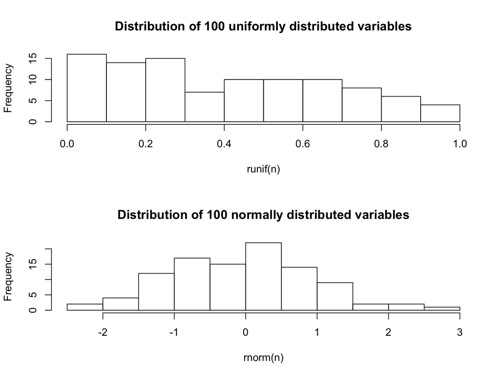

```r
n <- 100
par(mfrow = c(2, 1)) # 建立一個 2x1 的網格畫布
hist(runif(n), main = paste("Distribution of", n, "uniformly distributed variables")) # 試著增加隨機數的個數 n
hist(rnorm(n), main = paste("Distribution of", n, "normally distributed variables")) # 試著增加隨機數的個數 n
```

## 盒鬚圖

- `boxplot()` 繪製盒鬚圖
- 使用 `~` 運算子將類別變數納入

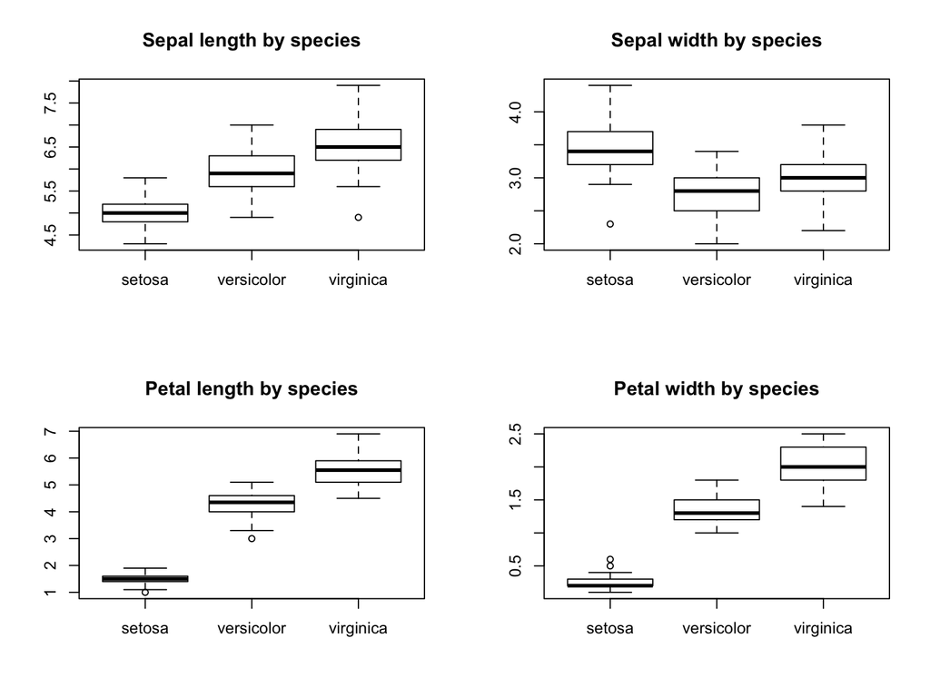

```r
str(iris)
par(mfrow = c(2, 2))
boxplot(iris$Sepal.Length ~ iris$Species, main = "Sepal length by species")
boxplot(iris$Sepal.Width ~ iris$Species, main = "Sepal width by species")
boxplot(iris$Petal.Length ~ iris$Species, main = "Petal length by species")
boxplot(iris$Petal.Width ~ iris$Species, main = "Petal width by species")
```

## 函數圖

- `curve()` 繪製函數圖

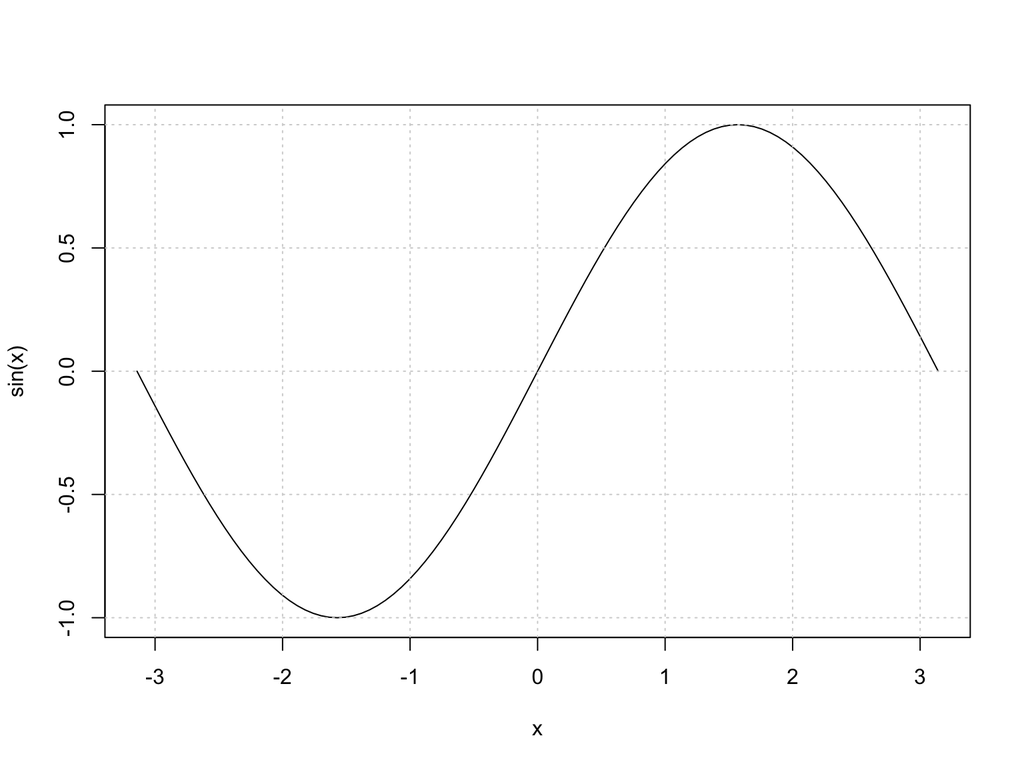

```r
curve(sin, from = -pi, to = pi)
grid()
```

## 函數圖（2）

- 繪製自訂函數也不是問題
- 我們會教同學如何自訂函數

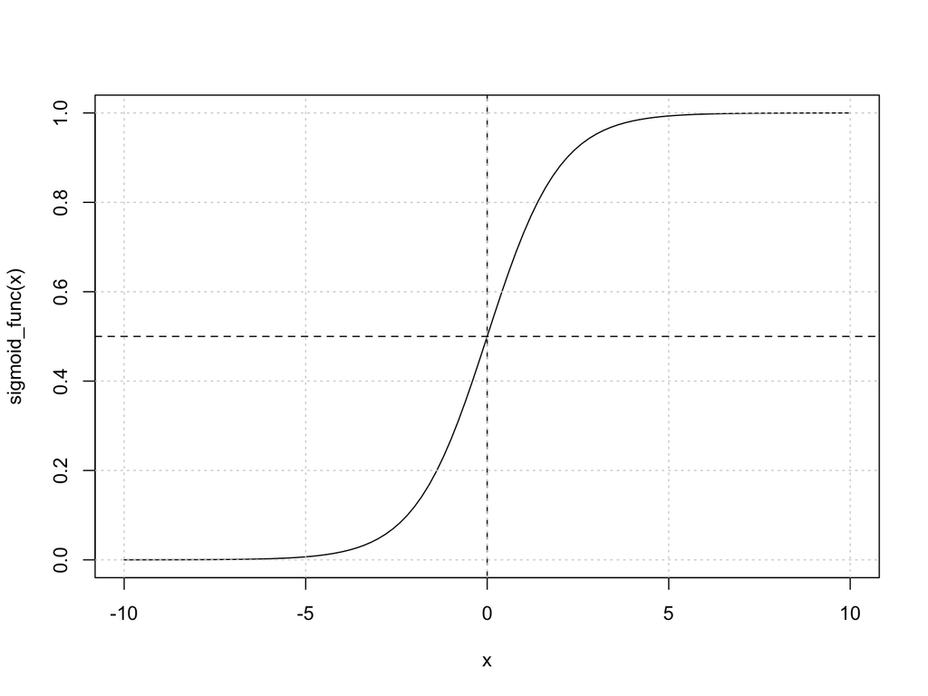

```r
sigmoid_func <- function(x){
  return(1 / (1 + exp(-x)))
}
curve(sigmoid_func, from = -10, to = 10)
abline(h = 0.5, lty = 2)
abline(v = 0, lty = 2)
grid()
```

## 長條圖

- `barplot()` 繪製長條圖

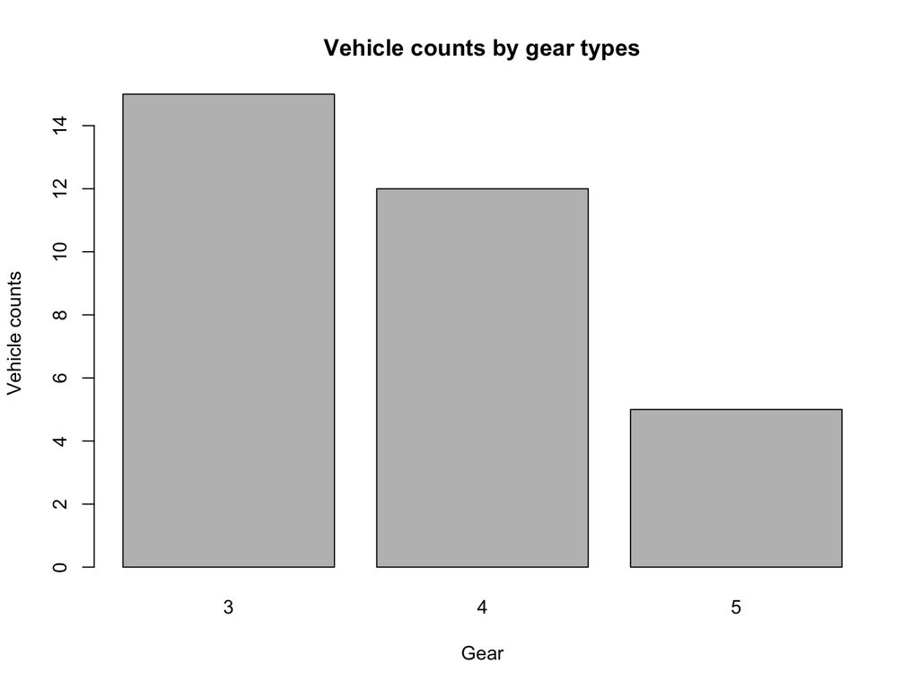

```r
tbl_gear <- table(mtcars$gear)
barplot(tbl_gear, main = "Vehicle counts by gear types",
        xlab = "Gear", ylab = "Vehicle counts")
```

## 長條圖（2）

- 不只能呈現 count
- 練習畫出下圖

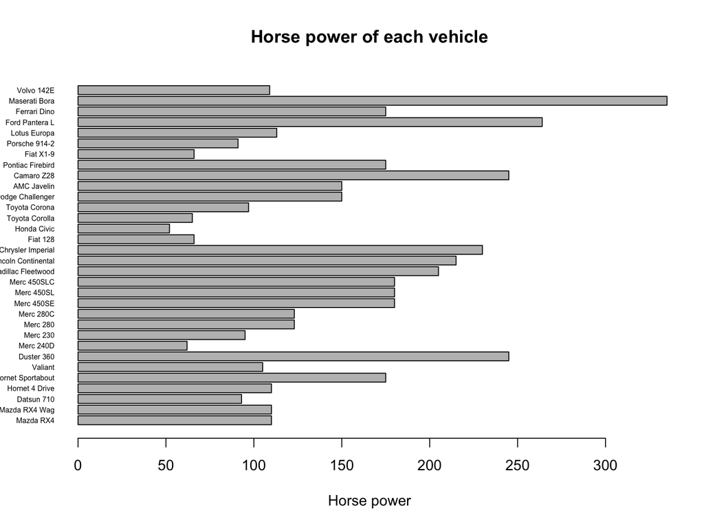

## 長條圖（3）

- 在 bar 上方顯示數值

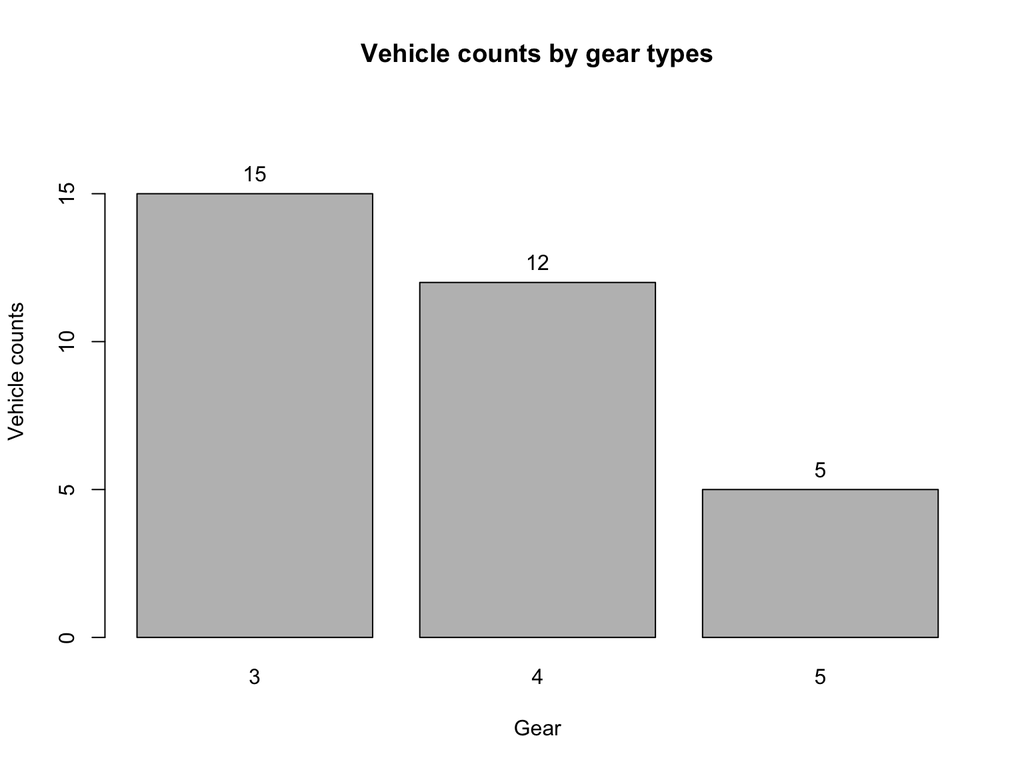

```r
y_lim <- c(0, 1.2 * max(table(mtcars$gear)))
bar_plt <- barplot(table(mtcars$gear), main = "Vehicle counts by gear types", xlab = "Gear", ylab = "Vehicle counts", ylim = y_lim)
text(x = bar_plt, y = table(mtcars$gear), label = table(mtcars$gear), pos = 3)
```

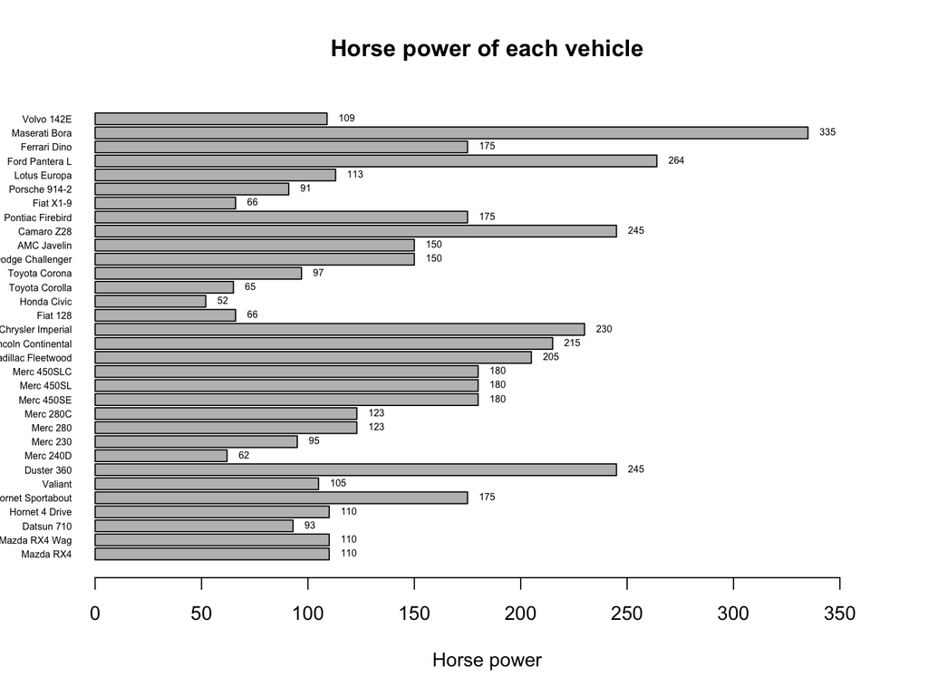

```r
vehicle_names <- row.names(mtcars)
x_lim <- c(0, 1.1 * max(mtcars$hp))
bar_plt <- barplot(mtcars$hp, names = vehicle_names, main = "Horse power of each vehicle", xlab = "Horse power", horiz = TRUE, las = 1, cex.names = 0.5, xlim = x_lim)
text(x = mtcars$hp, y = bar_plt, label = mtcars$hp, pos = 4, cex = 0.5)
```

## （Optional）氣泡圖

- 首先準備資料 `country`

```r
library(DBI)

con <- dbConnect(RMySQL::MySQL(),
                 dbname = "world",
                 host = "rsqltrain.ced04jhfjfgi.ap-northeast-1.rds.amazonaws.com",
                 port = 3306,
                 user = "trainstudent",
                 password = "csietrain")
country <- dbReadTable(con, "country")
dbDisconnect(con)
```

## （Optional）氣泡圖（2）

- 利用 `symbols()` 函數繪畫

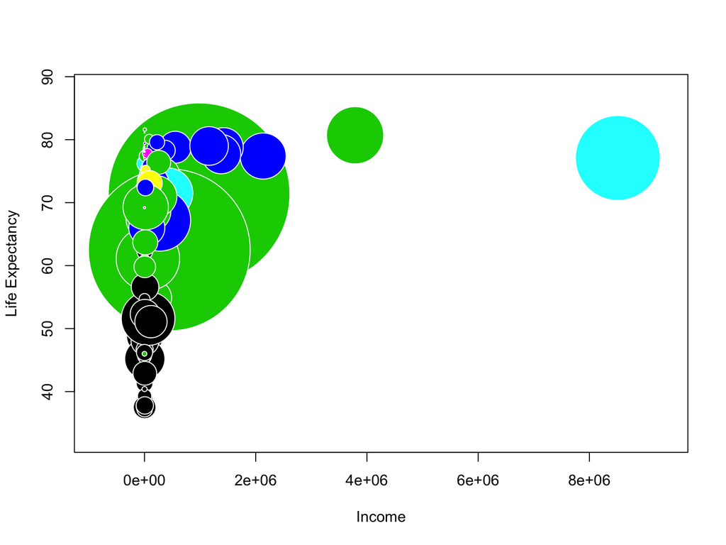

```r
symbols(country$GNP, country$LifeExpectancy, circles = sqrt(country$Population / pi),
        bg = factor(country$Continent), fg = "white",
        xlab = "Income", ylab = "Life Expectancy")
```

## （Optional）將 `ylab` 轉換成水平

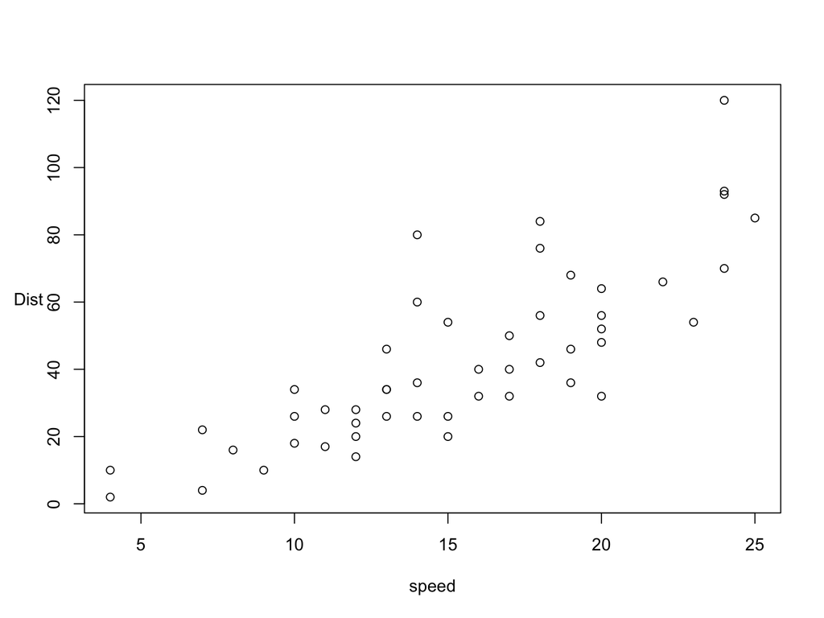

```r
?mtext
plot(cars, ylab = "")
mtext("Dist", side = 2, las = 1, line = 2)
```

```r
#mtext("Dist", side = 2, las = 1, at = max(cars$dist) * 1.2)
```

## 如何學習作圖

- 查字典 vs. 讀字典
- 學習如何搜尋關鍵字

## 期中作業

- 用一個 2x2 的畫布練習使用 Base plotting system 繪製任意四個圖形